# Palinha da Lista 2

Luizao,Lubao,Hidekao

Instalando pacotes.

```r
if(!require(dplyr)){install.packages("dplyr")}
library(dplyr)
### matrix termo doc
if(!require(tm)){install.packages("tm")}
library(tm)
### operacoes na matrix termo-doc
if(!require(slam)){install.packages("slam")}
library(slam)
### bibliotecas de stopwords
if(!require(stopwords)){install.packages("stopwords")}
library(stopwords)
### bibliotecas de stopwords
if(!require(SnowballC)){install.packages("SnowballC")}
library(SnowballC)
### nuvem de palavras
if(!require(wordcloud)){install.packages("wordcloud")}
library(wordcloud)
### bibliotecas de stopwords
if(!require(RColorBrewer)){install.packages("RColorBrewer")}
library(RColorBrewer)
### KNN
if(!require(FNN)){install.packages("FNN")}
library(FNN)
### reg com lasso e sem
if(!require(glmnet)){install.packages("glmnet")}
library(glmnet)
### grafico
if(!require(ggplot2)){install.packages("ggplot2")}
library(ggplot2)
if(!require(ggpubr)){install.packages("ggpubr")}
library(ggpubr)
if(!require(gridExtra)){install.packages("gridExtra")}
library(gridExtra)
### Matriz esparsa geral
if(!require(Matrix)){install.packages("Matrix")}
library(Matrix)
### Random Forest
if(!require(ranger)){install.packages("ranger")}
library(ranger)
### Rede neural
if(!require(keras)){install.packages("keras")}
library(keras)
### XGBBoost
if(!require(xgboost)){install.packages("xgboost")}
library(xgboost)
```

# Exercício 1

Hideki da pós.

# Exercício 2

## Item (a)

Lendo os colunas necessárias e removendo as observações com NA.

```r
library(readr)
TMDb_updated = read_csv("TMDb_updated.CSV/TMDb_updated.CSV")
```

```r
### Pegando apenas as colunas indicadas pelo exercicio
dados = TMDb_updated[,c(3,6)]

#=============================================
##### Faz o percentual do numero de NA
pMiss <- function(x){sum(is.na(x))/length(x)*100}
### Tem NA na coluna overview
apply(dados,2,pMiss)
```

```
##     overview vote_average
##          0.3          0.0
```

```r
dados1 = na.omit(dados)
```

Em seguida, faz-se o processo para obter a Matriz-Documento-Termo.

```r
resumo = VCorpus(VectorSource(dados1$overview),
                 readerControl = list(languague = "en"))

### Indicando as StopWords
resumo1 =  tm_map(resumo,
                 removeWords,
                 stopwords(language = "en",source = "smart"))

### Criando a matriz documento termo
dtm = resumo1 %>%
  DocumentTermMatrix(control = list(tolower=T,
                                    removePunctuation = T,
                                    removeNumbers = T,
                                    stripWhitespace = T,
                                    stopwords = T,
                                    stemming = T,
                                    weighting= weightTfIdf))

### Mantem somente as palavras que
## se repetem mais de 5% o
dtm2 = removeSparseTerms(dtm,0.95)
```

Ao longo de todo o exercício 2, será trabalhado com a frequência inversa normalizada (**weightTfIdf**).

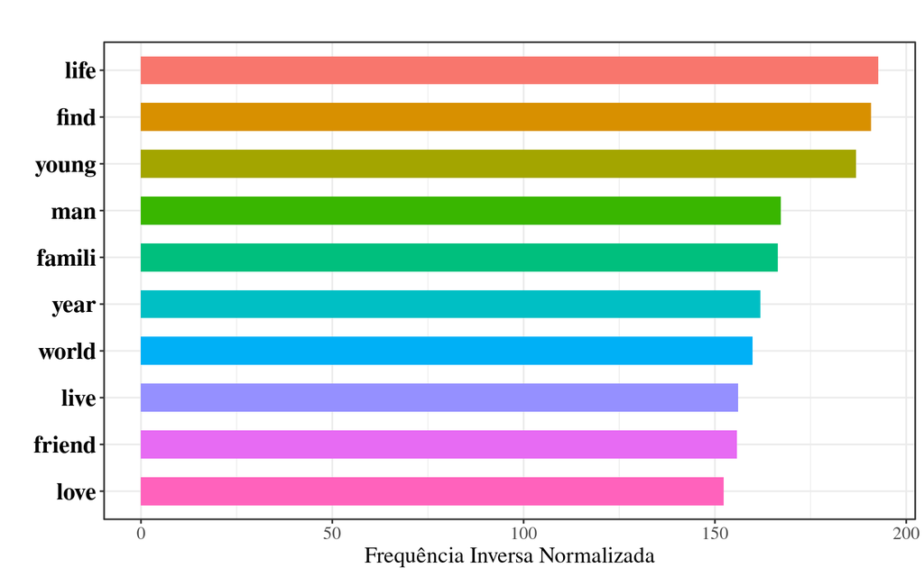

Frequência inversa normalizada

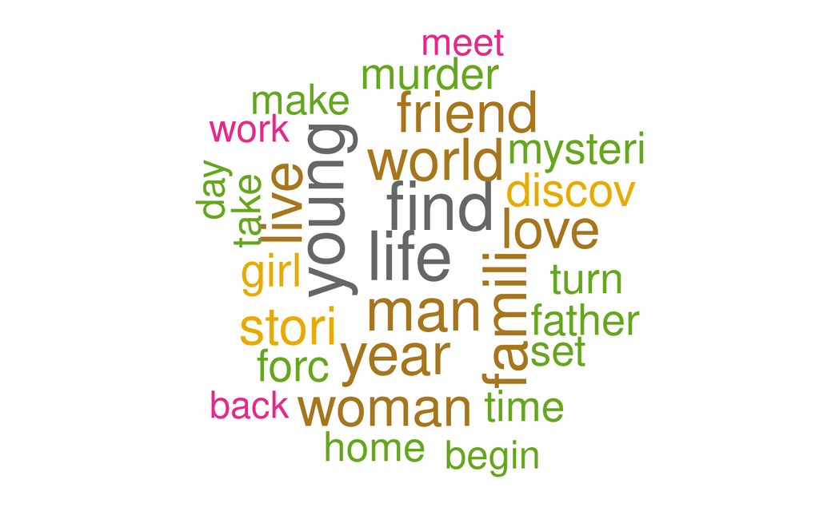

Frequência inversa normalizada

Mas além de explorar a (**weightTfIdf**), é interessante verificar visualmente a própria frequência absoluta das palavras.

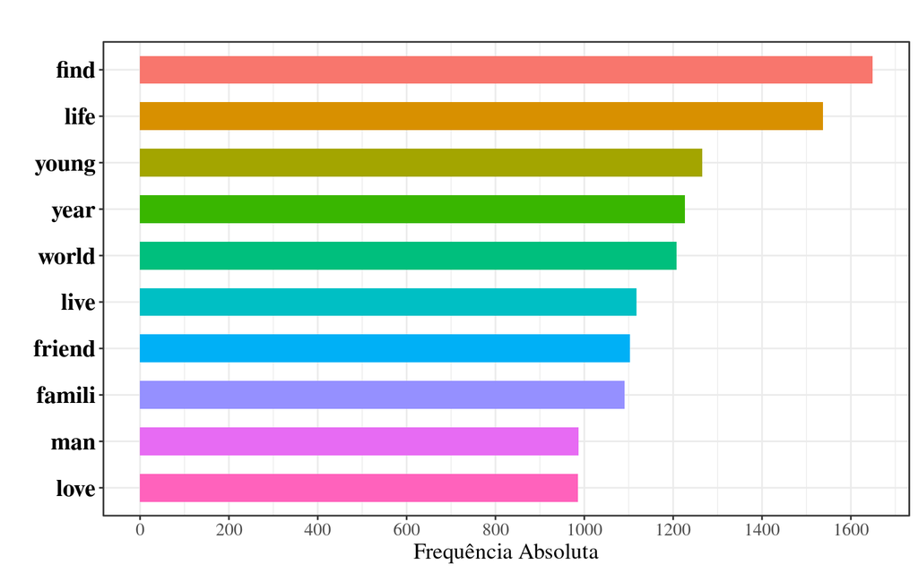

Frequência absoluta

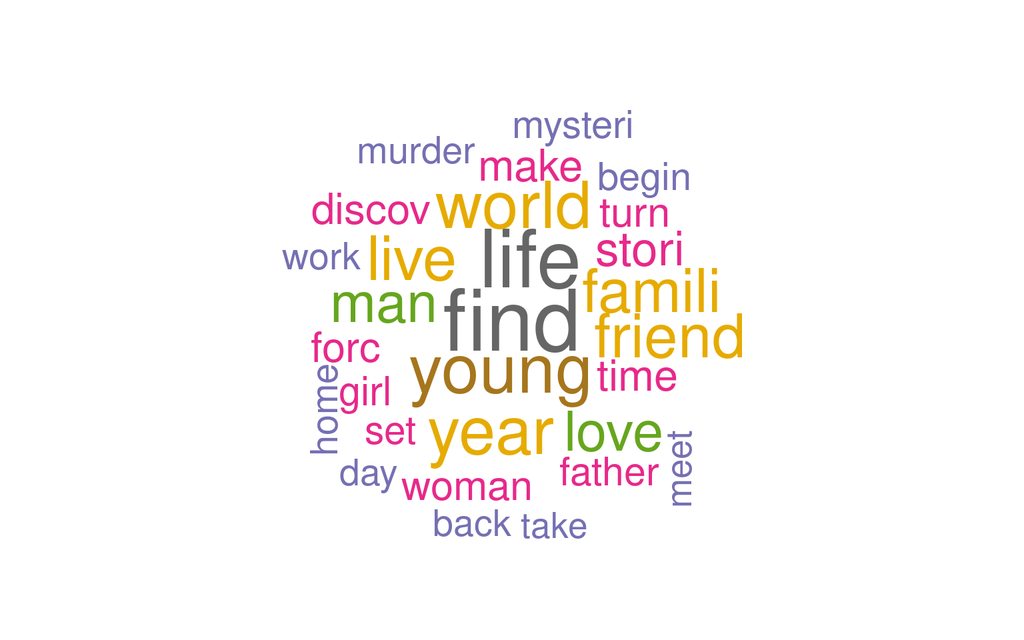

Frequência absoluta

Divide-se os dados em treinamento, teste e validação.

```r
#=============================================
##### Data Split
set.seed(37)
split = sample(c("Treino","Valida","Teste"),prob=c(0.6,0.2,0.2),
               size = nrow(dados1),replace = T)

### Dividindo o variavel resposta
notas_treino = dados1$vote_average[split == "Treino"]
notas_valida = dados1$vote_average[split == "Valida"]
notas_teste = dados1$vote_average[split == "Teste"]

split_treino_tudo = as.logical(c(c(split == "Treino") +
                                   c(split == "Valida")))

notas_treino_tudo =
  dados1$vote_average[split_treino_tudo]

### Divivindo as covariaveis
dtm_treino = dtm2[split == "Treino",]
dtm_valida = dtm2[split == "Valida",]
dtm_teste = dtm2[split == "Teste",]

dtm_treino_tudo =
  dtm2[split_treino_tudo,]

n_teste = nrow(dtm_teste)
```

Ademais, como será calculado o risco, define-se funções para facilitar as pŕoximas operações. Salienta-se que foi escolhido o erro quadrático médio.

```r
riscos = list()

calcula_EQM = function(preditos,y_teste){
  return(mean((y_teste - preditos)**2))
}

calcula_VAR_EQM = function(preditos,y_teste){
  EQM = calcula_EQM(preditos,y_teste)
  valor = mean(((y_teste - preditos)**2 - EQM)**2)
  return(valor)
}

calcula_IC = function(Eqm,Var,n){
  c(Eqm - 2*sqrt( (1/n)*Var ),
    Eqm + 2*sqrt( (1/n)*Var ))
}

calcula_EQM_e_IC = function(preditos,y_teste,n){
  EQM = calcula_EQM(preditos,y_teste)
  Var = calcula_VAR_EQM(preditos,y_teste)
  vetor = c(EQM,calcula_IC(EQM,Var,n))
  return(vetor)
}
```

## Item (b) - KNN

Utilizando a amostra de validação, encontra-se o melhor K possível para o método do KNN.

```r
#=============================================
##### Fazendo o laco do KNN com o conjunto
#### de validacao

k.grid = round(seq(1,100,length.out=50))
erro = rep(NA,length(k.grid))
start_time <- Sys.time()
for(ii in seq_along(k.grid)){

  predito = knn.reg(train = dtm_treino,
                    y = notas_treino,
                    k=k.grid[ii],
                    test = dtm_valida)$pred

  erro[ii] = calcula_EQM(predito,notas_valida)
}
end_time <- Sys.time()
end_time - start_time
```

```
## Time difference of 9.21794 secs
```

```r
best.k = k.grid[which.min(erro)]
### Melhor k
best.k
```

```
## [1] 98
```

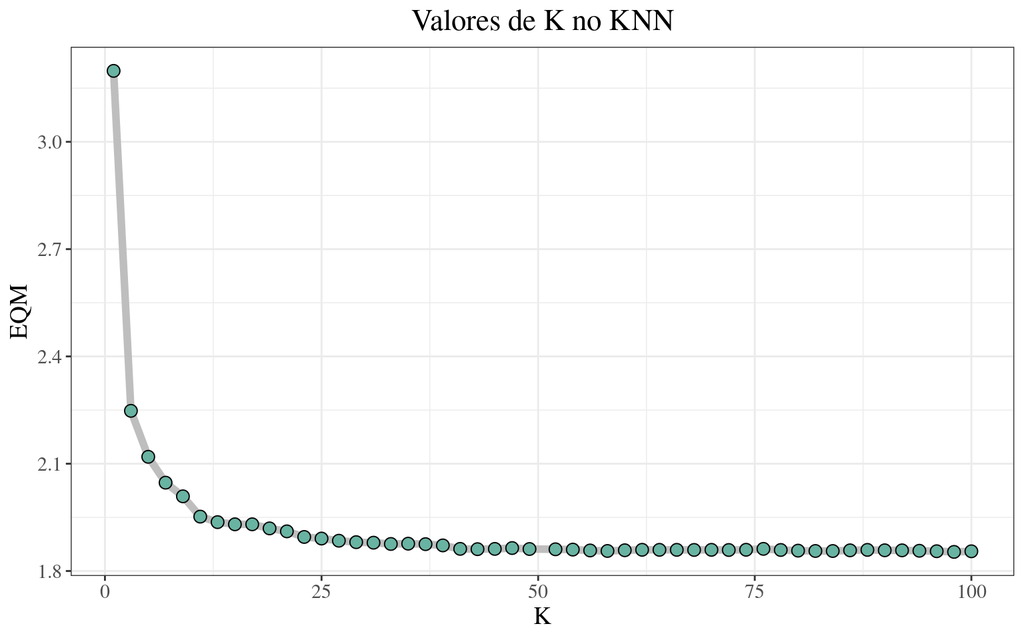

Escolhido o k, basta calcular o risco e seu intervalo na amostra de teste.

```r
#=============================================
##### Fazendo o KNN na amostra Teste
predito_knn =
  knn.reg(train = dtm_treino_tudo,
          y = notas_treino_tudo,
          k= best.k,
          test = dtm_teste)$pred

riscos$knn = calcula_EQM_e_IC(predito_knn,notas_teste,n_teste)
riscos
```

```
## $knn
## [1] 1.837548 1.556503 2.118593
```

## Item (c) - Regressão Linear

É importante enaltecer que a Matrix-Documento-Termo do pacote **tm** retorna uma matriz esparsa escrita por meio do formato **simple triplet matrix sparse**, e este não é aceito no pacote **glmnet**. Desse modo, transforma-se a Matrix-Documento-Termo em um outro formato de matrix esparsa, que é **dgCMatrix** do pacote **Matrix**.

### Sem Lasso

```r
### Funcao para transformar de triplet matrix sparse
## para dgCMatrix.
CANIBAL.as.sparseMatrix <- function(simple_triplet_matrix_sparse) {
  sparseMatrix(
    i = simple_triplet_matrix_sparse$i,
    j = simple_triplet_matrix_sparse$j,
    x = simple_triplet_matrix_sparse$v,
    dims = c(
      simple_triplet_matrix_sparse$nrow,
      simple_triplet_matrix_sparse$ncol
    ),
    dimnames = dimnames(simple_triplet_matrix_sparse)
  )
}

### Executando o modelo de regressao linear
modelo_reg_linear <-
  glmnet(x = CANIBAL.as.sparseMatrix(dtm_treino_tudo),
         y = notas_treino_tudo,
         alpha = 0, lambda = 0,
         stantardize = T)
```

Obtendo-se assim os seguintes coeficientes

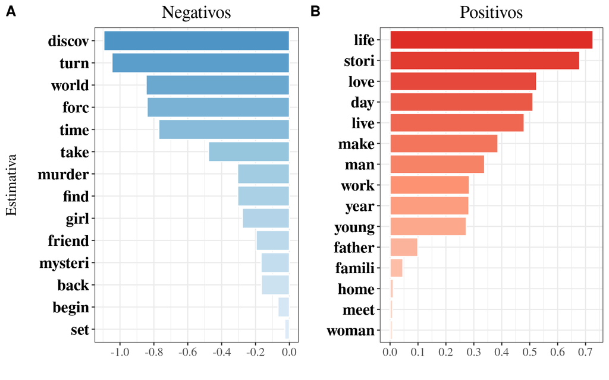

Coeficientes na Regressão Linear

Calcula-se o risco para a regressão linear.

```r
#=============================================
##### Fazendo a Reg Linear na amostra Teste
predito_linear =
  predict(modelo_reg_linear,
          newx = CANIBAL.as.sparseMatrix(dtm_teste))

riscos$RegLinear =
  calcula_EQM_e_IC(predito_linear,notas_teste,n_teste)

riscos
```

```
## $knn
## [1] 1.837548 1.556503 2.118593
##
## $RegLinear
## [1] 1.827838 1.546167 2.109509
```

### Com Lasso

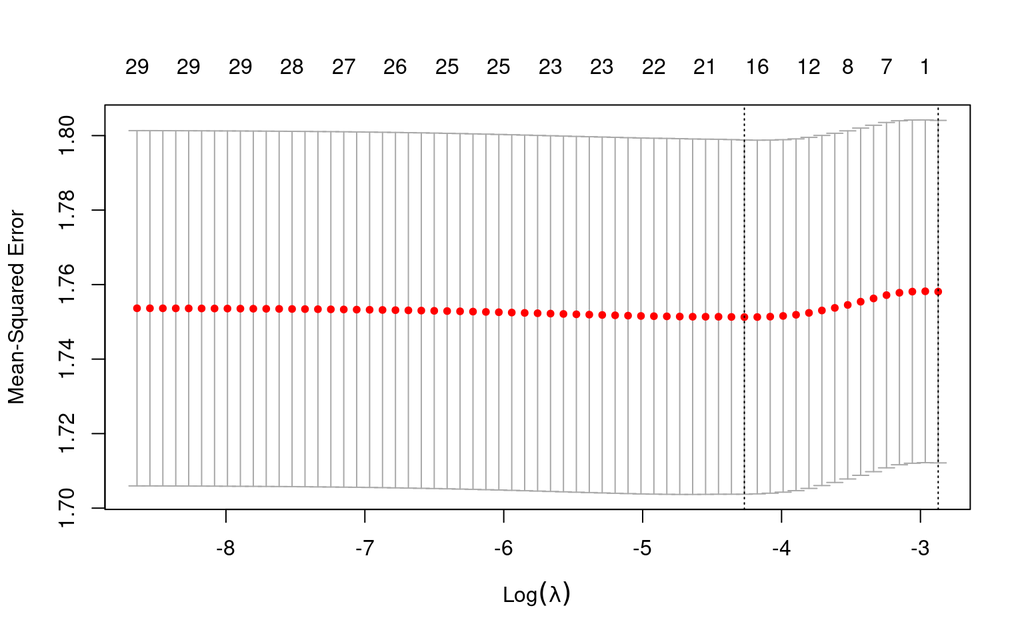

```r
cv_lasso <-
  cv.glmnet(x=CANIBAL.as.sparseMatrix(dtm_treino_tudo),
            y=notas_treino_tudo,
            alpha = 1,nfolds = 10,
            stantardize = T)

plot(cv_lasso)
```

```r
modelo_reg_lasso =
  glmnet(x=CANIBAL.as.sparseMatrix(dtm_treino_tudo),
         y=notas_treino_tudo,
         alpha=1,
         lambda = cv_lasso$lambda.min,
         stantardize = T)
```

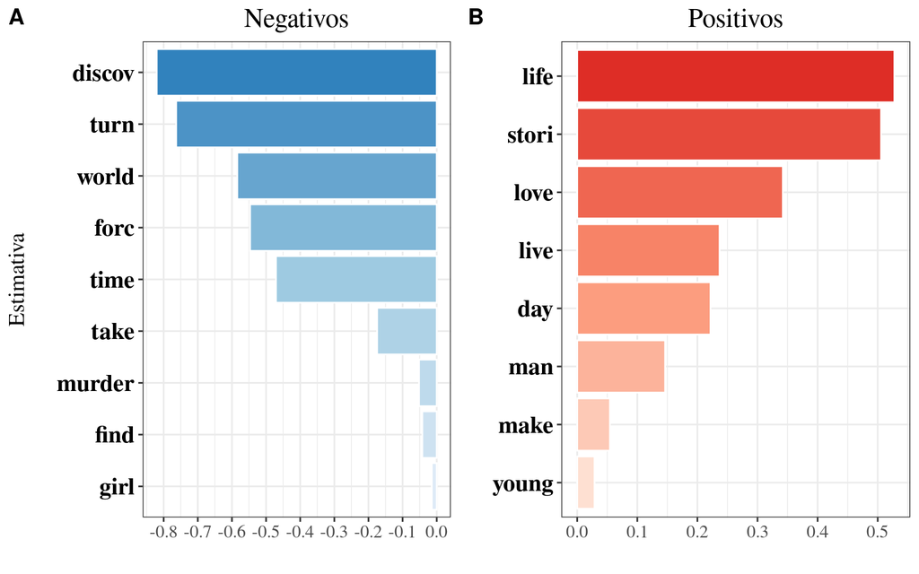

Coeficientes na Regressão Linear com o Lasso

Calcula-se o risco para a regressão linear com lasso.

```r
#=============================================
##### Fazendo a Reg Linear Lasso na amostra Teste
predito_lasso =
  predict(modelo_reg_lasso,
          newx = CANIBAL.as.sparseMatrix(dtm_teste))

riscos$RegLinearLasso =
  calcula_EQM_e_IC(predito_lasso,notas_teste,n_teste)

riscos
```

```
## $knn
## [1] 1.837548 1.556503 2.118593
##
## $RegLinear
## [1] 1.827838 1.546167 2.109509
##
## $RegLinearLasso
## [1] 1.827373 1.546590 2.108155
```

## Item (d) - Floresta Aleatória

```r
#=============================================
##### Fazendo a floresta

floresta =
  ranger(x = CANIBAL.as.sparseMatrix(dtm_treino_tudo),
         y = notas_treino_tudo,
         importance = "impurity")
```

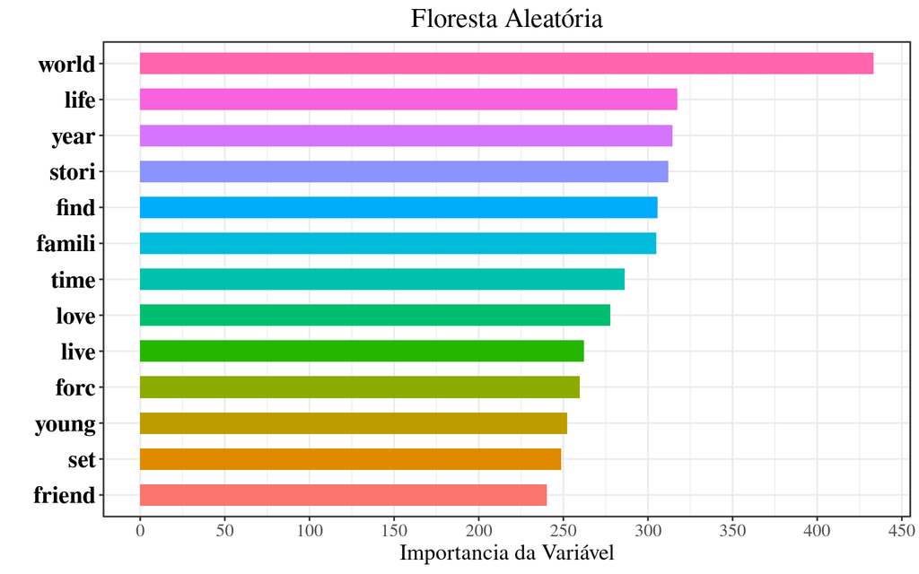

Calcula-se o risco da floresta.

```r
#=============================================
##### Fazendo o predito
predito_floresta =
  predict(floresta,
          CANIBAL.as.sparseMatrix(dtm_teste))

riscos$Florestas =
  calcula_EQM_e_IC(predito_floresta$predictions,
                   notas_teste,n_teste)

riscos
```

```
## $knn
## [1] 1.837548 1.556503 2.118593
##
## $RegLinear
## [1] 1.827838 1.546167 2.109509
##
## $RegLinearLasso
## [1] 1.827373 1.546590 2.108155
##
## $Florestas
## [1] 1.942118 1.656946 2.227291
```

## Item (e) - XGBoost

```r
#=============================================
##### Mat do XGBoost
xgb_mat_treino_tudo =
  xgb.DMatrix(CANIBAL.as.sparseMatrix(dtm_treino_tudo),
              label = notas_treino_tudo)

xgb_mat_teste =
  xgb.DMatrix(CANIBAL.as.sparseMatrix(dtm_teste),
              label = notas_teste)

#=============================================
##### CV do xgb para escolher a iteracao

cv_xgb <- xgb.cv(data = xgb_mat_treino_tudo,
                 nrounds = 10000,
                 nfold = 10,
                 early_stopping_rounds = 300,
                 prediction = TRUE,
                 metric = "rmse",
                 verbose = 0,
                 objective = "reg:squarederror")

### Melhor iteracao
cv_xgb$evaluation_log[cv_xgb$best_iteration,]
```

```
##    iter train_rmse_mean train_rmse_std test_rmse_mean test_rmse_std
## 1:   12        1.232748    0.007052092        1.33496    0.07070348
```

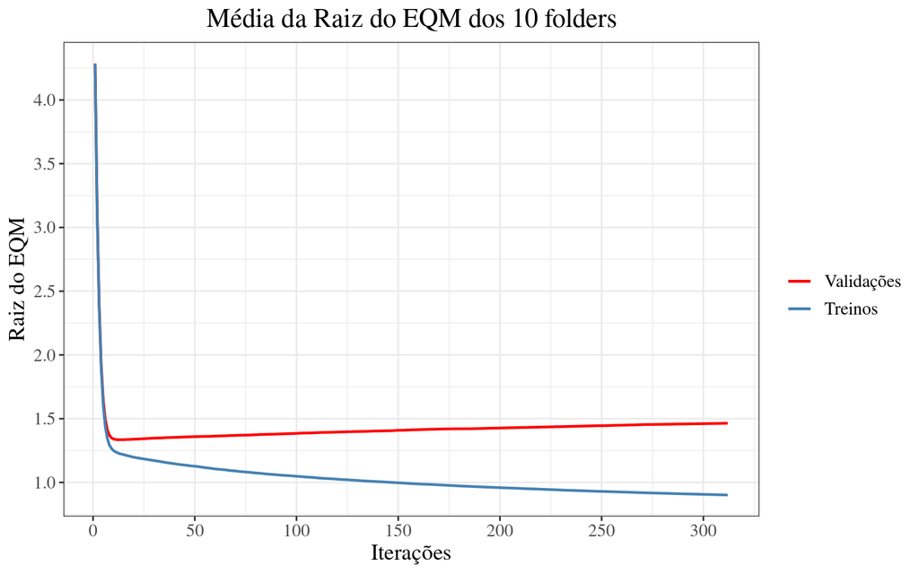

Early Stop no XGB

Escolhido o número de iterações com o Early Stop (utilizando uma validação cruzada em todo o treino), basta criar o modelo em si.

```r
#=============================================
##### Fazendo o XBG
modelo_xgb =
  xgboost(data = xgb_mat_treino_tudo,
      nrounds = cv_xgb$best_iteration,
      eval_metric = "rmse",
      verbose = 0,
      objective = "reg:squarederror")
```

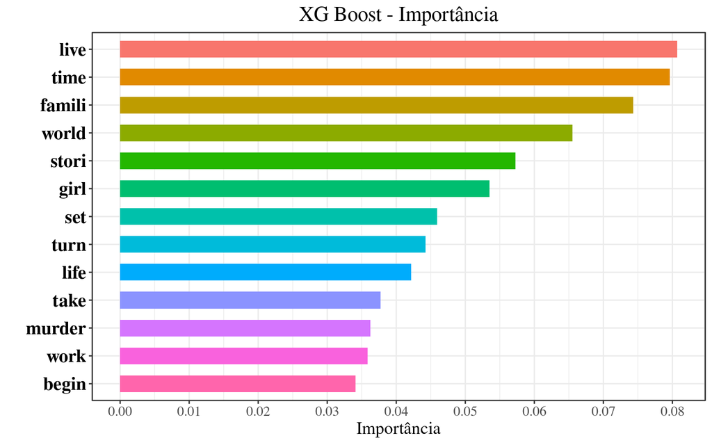

Calcula-se o risco.

```r
#=============================================
##### Fazendo o predito
predito_xgb =
  predict(modelo_xgb,xgb_mat_teste)
riscos$XGBoost =
  calcula_EQM_e_IC(predito_xgb,notas_teste,n_teste)

riscos
```

```
## $knn
## [1] 1.837548 1.556503 2.118593
##
## $RegLinear
## [1] 1.827838 1.546167 2.109509
##
## $RegLinearLasso
## [1] 1.827373 1.546590 2.108155
##
## $Florestas
## [1] 1.942118 1.656946 2.227291
##
## $XGBoost
## [1] 1.877408 1.604273 2.150542
```

## Item (f) - Rede Meupau

### Rede neural sem dropout

```r
install_keras()
```

```
##
## Installation complete.
```

```r
#=============================================
##### Voltando com as matrizes e padronizado
#### o treino tudo, e seus escalares sao usados
#### na amostra teste tambem.

mat_treino_tudo =
  as.matrix(CANIBAL.as.sparseMatrix(dtm_treino_tudo))

media_treino_tudo = data.frame(mat_treino_tudo) %>%
  summarise_all("mean")

sd_treino_tudo = data.frame(mat_treino_tudo) %>%
  summarise_all("sd")

mat_teste =
  as.matrix(CANIBAL.as.sparseMatrix(dtm_teste))

#=============================================
##### Forma geral da rede

modelo_neural = keras_model_sequential() %>%
  layer_dense(units=30,activation = "relu",
              input_shape = ncol(mat_treino_tudo)) %>%
  layer_dense(units=20,activation="relu") %>%
  layer_dense(units=5,activation = "relu") %>%
  layer_dense(units = 1)

#=============================================
##### Compilador da rede

compile(modelo_neural,
        loss="mse",
        optimizer= optimizer_rmsprop(),
        metrics = list("mean_absolute_error"))

#=============================================
##### Criterio de parada

parada_rede = callback_early_stopping(
  monitor = "val_loss",
  min_delta = 0,
  patience = 50,
  verbose = 1,
  mode = c("max"),
  #in max mode it will stop when
  #the quantity monitored has stopped
  #increasing
  baseline = NULL,
  restore_best_weights = FALSE
)

#=============================================
##### Rodando

start_time <- Sys.time()

historico = modelo_neural  %>%
  fit(scale(mat_treino_tudo,
            center=media_treino_tudo,scale=sd_treino_tudo),
      notas_treino_tudo,
      epochs = 200,
      batchsize = 300,
      validation_split=0.2,
      verboso=T,
      callbacks = parada_rede)

end_time <- Sys.time()
end_time - start_time
```

```
## Time difference of 10.66162 secs
```

Pelo algoritmo executado, tem-se que a rede neural parou na época 51 de um total de 200 épocas.

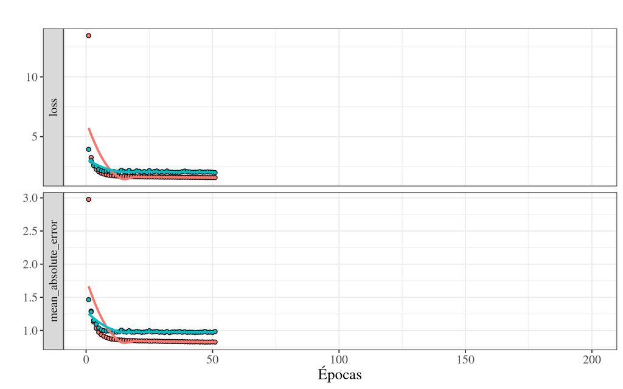

Rede Neural sem dropout - Comportamente do erro ao longo das épocas

Calcula-se o risco.

```r
#=============================================
##### Fazendo o predito
predito_neural =
  predict(modelo_neural,scale(mat_teste,
                              center=media_treino_tudo,
                              scale=sd_treino_tudo))

riscos$Rede_SemDropOut =
  calcula_EQM_e_IC(predito_neural,
                   notas_teste,n_teste)

riscos
```

```
## $knn
## [1] 1.837548 1.556503 2.118593
##
## $RegLinear
## [1] 1.827838 1.546167 2.109509
##
## $RegLinearLasso
## [1] 1.827373 1.546590 2.108155
##
## $Florestas
## [1] 1.942118 1.656946 2.227291
##
## $XGBoost
## [1] 1.877408 1.604273 2.150542
##
## $Rede_SemDropOut
## [1] 1.975015 1.706933 2.243098
```

### Rede Neural com Dropout

```
## Time difference of 11.01266 secs
```

[figure not shown]

Rede neural com dropout - Comportamento ao longo das épocas

```r
#=============================================
##### Forma geral da rede

modelo_neural2 = keras_model_sequential() %>%
  layer_dense(units=30,activation = "relu",
              input_shape = ncol(mat_treino_tudo)) %>%
  layer_dropout(0.2) %>%
  layer_dense(units=20,activation="relu") %>%
  layer_dropout(0.2) %>%
  layer_dense(units=5,activation = "relu") %>%
  layer_dense(units = 1)

#=============================================
##### Compilador da rede

compile(modelo_neural2,
        loss="mse",
        optimizer= optimizer_rmsprop(),
        metrics = list("mean_absolute_error"))

#=============================================
##### Criterio de parada

parada_rede = callback_early_stopping(
  monitor = "val_loss",
  min_delta = 0,
  patience = 50,
  verbose = 1,
  mode = c("max"),
  #in max mode it will stop when
  #the quantity monitored has stopped
  #increasing
  baseline = NULL,
  restore_best_weights = FALSE
)


#=============================================
##### Rodando

start_time <- Sys.time()
historico2 = modelo_neural2  %>%
  fit(scale(mat_treino_tudo,
            center=media_treino_tudo,scale=sd_treino_tudo),
      notas_treino_tudo,
      epochs = 200,
      batchsize = 300,
      validation_split=0.2,
      verboso=T,
      callbacks = parada_rede)

end_time <- Sys.time()
end_time - start_time
```

Caucula-se o risco

```r
#=============================================
##### Fazendo o predito
predito_neural2 =
  predict(modelo_neural2,scale(mat_teste,
                              center=media_treino_tudo,
                              scale=sd_treino_tudo))

riscos$Rede_ComDropOut =
  calcula_EQM_e_IC(predito_neural2,
                   notas_teste,n_teste)

riscos
```

```
## $knn
## [1] 1.837548 1.556503 2.118593
##
## $RegLinear
## [1] 1.827838 1.546167 2.109509
##
## $RegLinearLasso
## [1] 1.827373 1.546590 2.108155
##
## $Florestas
## [1] 1.942118 1.656946 2.227291
##
## $XGBoost
## [1] 1.877408 1.604273 2.150542
##
## $Rede_SemDropOut
## [1] 1.975015 1.706933 2.243098
##
## $Rede_ComDropOut
## [1] 1.826032 1.550055 2.102009
```

## Item (g) - Kernel ridge regression

Hideki da pós.

## Item (h) - Preditos versus Observados

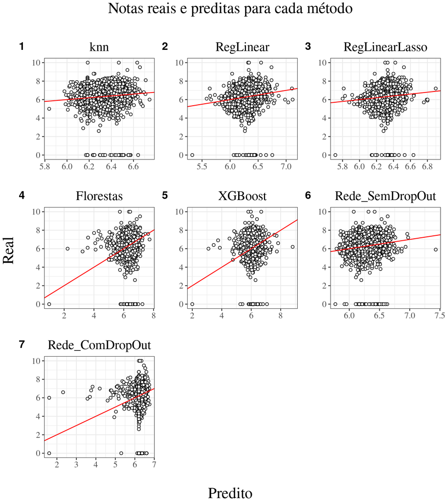